# 市场观察

2016/08/19

## 一、指数估值

### (一)指数动态市盈率

核心指数成分股的动态市盈率中位数走势如下图所示：

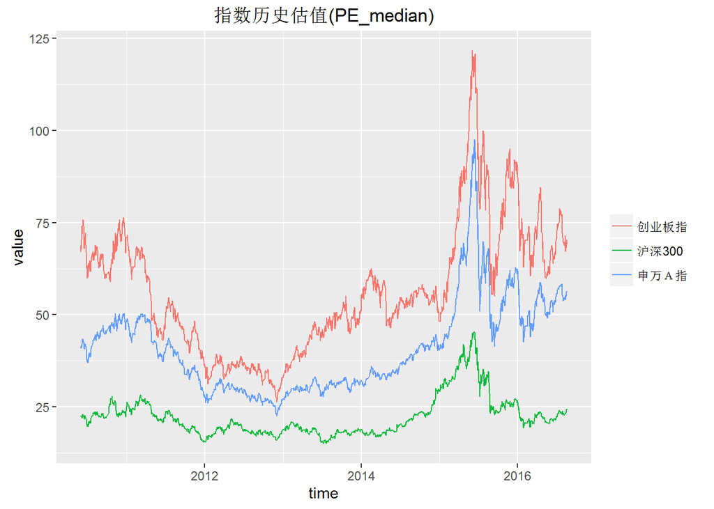

### (二)指数动态市盈率百分位

核心指数上述数据的百分位走势如下图所示：

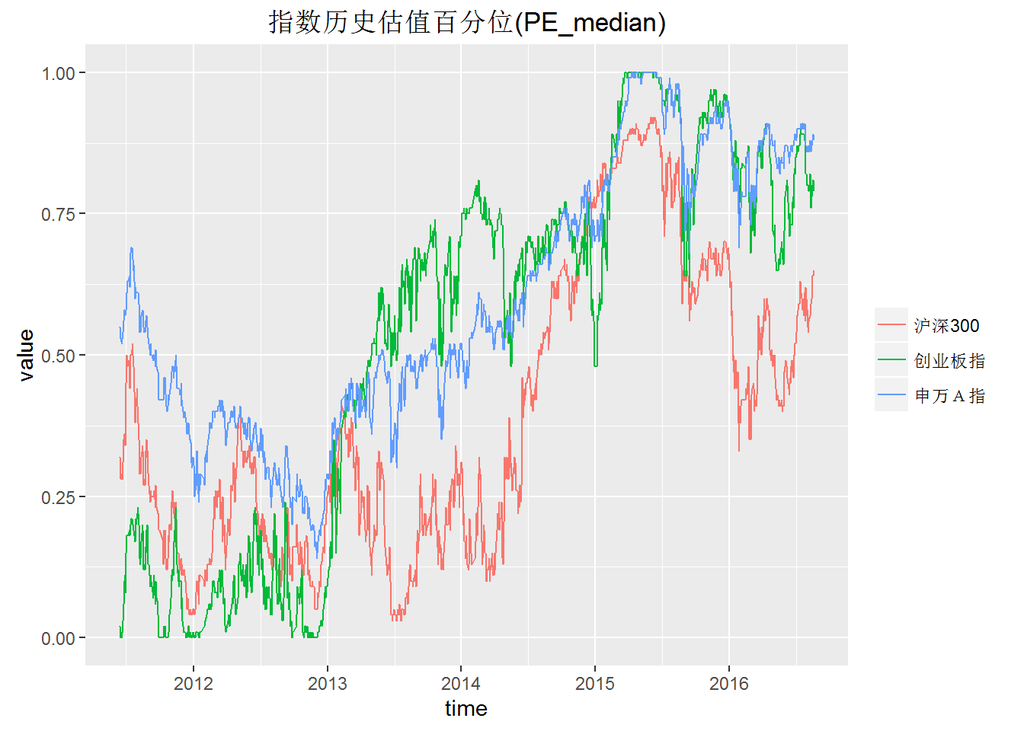

### (三)指数估值概览

纳入观察的18只指数最新的估值情况如下表：

| 日期 | 指数代码 | 指数简称 | 动态市盈率 | 上周动态市盈率 | 市盈率百分位 | 上周市盈率百分位 | 动态市净率 | 市净率百分位 |
| --- | --- | --- | --- | --- | --- | --- | --- | --- |
| 2016-08-18 | EI000979 | 大宗商品 | 51.95 | 50.76 | 0.98 | 0.97 | 2.54 | 0.47 |
| 2016-08-18 | EI000805 | A股资源 | 61.89 | 54.28 | 0.97 | 0.93 | 2.54 | 0.59 |
| 2016-08-18 | EI000819 | 有色金属 | 71.16 | 65.81 | 0.97 | 0.92 | 4.19 | 0.86 |
| 2016-08-18 | EI801003 | 申万Ａ指 | 56.13 | 54.15 | 0.88 | 0.86 | 4.85 | 0.77 |
| 2016-08-18 | EI399005 | 中小板指P | 47.57 | 48.81 | 0.84 | 0.85 | 5.76 | 0.75 |
| 2016-08-18 | EI399959 | 军工指数 | 97.00 | 92.96 | 0.83 | 0.79 | 6.63 | 0.82 |
| 2016-08-18 | EI000998 | 中证TMT | 63.22 | 57.75 | 0.82 | 0.75 | 6.49 | 0.82 |
| 2016-08-18 | EI399330 | 深证100 | 35.77 | 33.75 | 0.80 | 0.73 | 4.68 | 0.79 |
| 2016-08-18 | EI399006 | 创业板指 | 69.01 | 67.17 | 0.79 | 0.76 | 8.05 | 0.80 |
| 2016-08-18 | EI000933 | 中证医药 | 40.07 | 39.88 | 0.70 | 0.70 | 4.73 | 0.47 |
| 2016-08-18 | EI000300 | 沪深300 | 24.39 | 23.28 | 0.65 | 0.59 | 2.60 | 0.48 |
| 2016-08-18 | EI000808 | 医药生物 | 40.66 | 39.88 | 0.65 | 0.55 | 5.47 | 0.64 |
| 2016-08-18 | EI000905 | 中证500 | 39.99 | 39.49 | 0.64 | 0.63 | 3.76 | 0.63 |
| 2016-08-18 | EI801120 | 申万食品饮料 | 43.01 | 43.48 | 0.64 | 0.66 | 4.55 | 0.60 |
| 2016-08-18 | EI000827 | 中证环保 | 39.51 | 37.77 | 0.56 | 0.50 | 4.02 | 0.71 |
| 2016-08-18 | EI000932 | 中证消费 | 33.22 | 33.01 | 0.51 | 0.51 | 4.34 | 0.47 |
| 2016-08-18 | EI000934 | 中证金融 | 16.35 | 15.08 | 0.44 | 0.26 | 2.37 | 0.54 |
| 2016-08-18 | EI000016 | 上证50 | 12.75 | 12.02 | 0.16 | 0.09 | 1.65 | 0.14 |

## 二、基差

### (一)基差走势

三大股指期货隔季合约基差走势如下图：

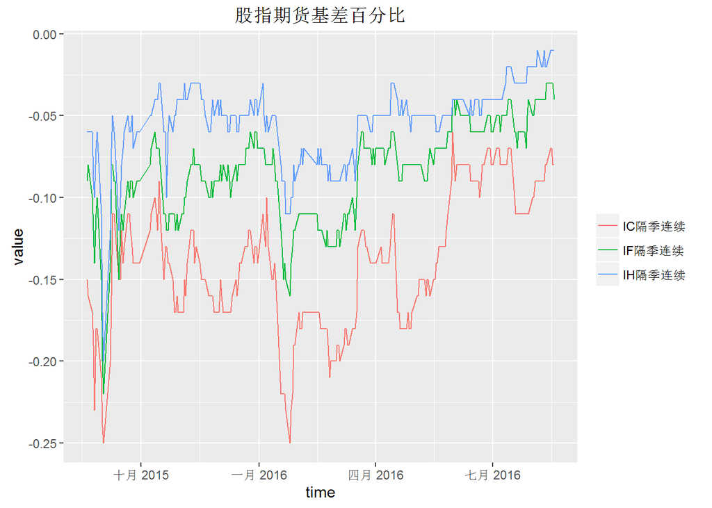

### (二)基差概况

三大股指期货连续合约基差概况如下表：

| 日期 | 合约简称 | 合约收盘价 | 基差 | 基差百分比 | 上周基差 | 上周基差百分比 |
| --- | --- | --- | --- | --- | --- | --- |
| 2016-08-18 | IH当月连续 | 2245.8 | 1.08 | 0.00 | -4.26 | 0.00 |
| 2016-08-18 | IH下月连续 | 2239.0 | -5.72 | 0.00 | -15.06 | -0.01 |
| 2016-08-18 | IH下季连续 | 2230.6 | -14.12 | -0.01 | -24.06 | -0.01 |
| 2016-08-18 | IH隔季连续 | 2221.4 | -23.32 | -0.01 | -34.06 | -0.02 |
| 2016-08-18 | IF当月连续 | 3365.6 | 1.11 | 0.00 | -7.16 | 0.00 |
| 2016-08-18 | IF下月连续 | 3336.0 | -28.49 | -0.01 | -31.76 | -0.01 |
| 2016-08-18 | IF下季连续 | 3279.6 | -84.89 | -0.03 | -85.36 | -0.03 |
| 2016-08-18 | IF隔季连续 | 3244.2 | -120.29 | -0.04 | -121.36 | -0.04 |
| 2016-08-18 | IC当月连续 | 6484.6 | -5.81 | 0.00 | -30.31 | 0.00 |
| 2016-08-18 | IC下月连续 | 6379.8 | -110.61 | -0.02 | -134.51 | -0.02 |
| 2016-08-18 | IC下季连续 | 6159.4 | -331.01 | -0.05 | -339.31 | -0.05 |
| 2016-08-18 | IC隔季连续 | 5956.6 | -533.81 | -0.08 | -520.51 | -0.08 |

## 三、套利

### (一)复牌股票套利

近两天复牌股票套利情况如下表：

[1] “无复牌股票套利”

### (二)定增基金跟踪

截止2016-08-19定增基金数据如下表，明细数据参见钱瀚的模板。

| 代码 | 名称 | 到期日期 | 最新净值 | 昨日收盘价 | 折溢价率 | 整体隐含折价率 | 大盘回撤0.1净值回撤 |
| --- | --- | --- | --- | --- | --- | --- | --- |
| 168101.OF | 九泰锐智 | 20200814 | 1.38 | 1.38 | 0.01 | 0.13 | -0.05 |
| 168102.OF | 九泰锐富 | 20210204 | 1.02 | 1.03 | 0.01 | 0.05 | -0.01 |
| 161225.OF | 国投瑞盈 | 20161119 | 1.05 | 1.03 | -0.02 | 0.04 | -0.08 |
| 501001.OF | 财通精选 | 20170101 | 1.11 | 1.05 | -0.06 | 0.01 | -0.09 |
| 501015.OF | 财通升级 | 20170908 | 1.03 | 1.00 | -0.03 | 0.09 | -0.03 |
| 160518.OF | 博时睿远 | 20171016 | 1.01 | 1.00 | -0.01 | 0.04 | -0.01 |

定增基金近期的净值走势如下图：

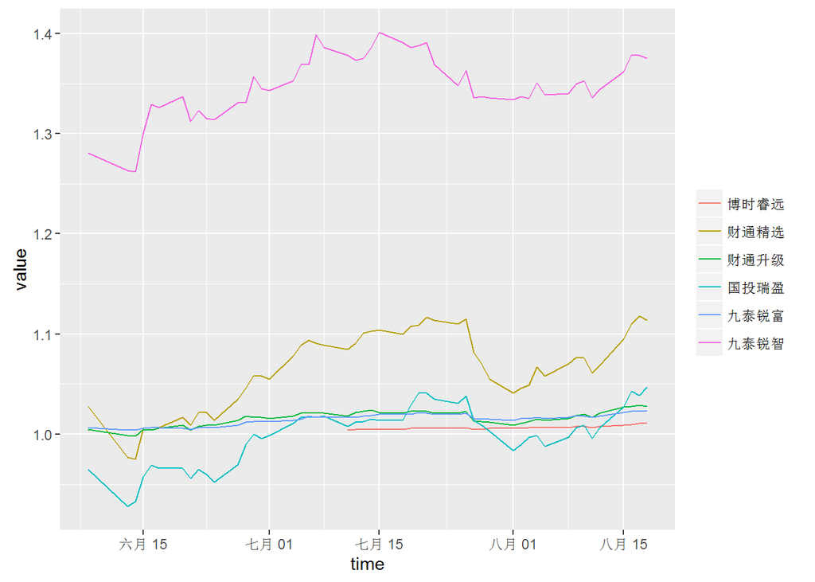

定增基金近期的折溢价走势如下图：

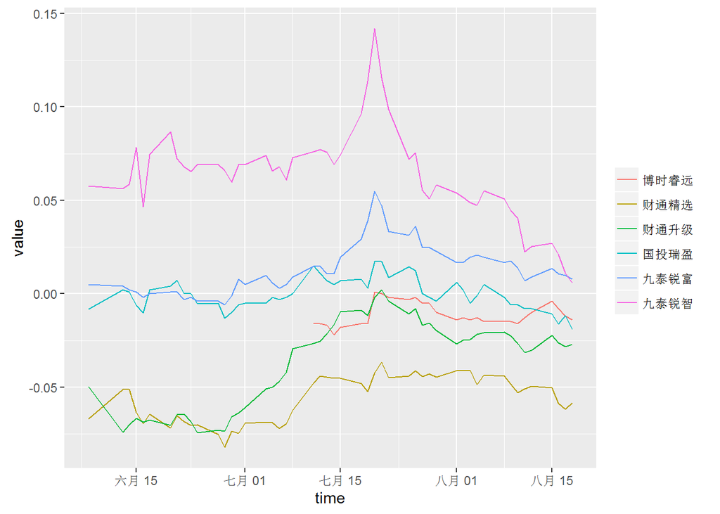

## 四、择时

### (一)大盘均线强弱指数

大盘均线强弱指数在一定程度上可以视为一个反转指标，当大盘均线得分接近8分时，预示市场接近顶部，当大盘均线得分接近0分时，预示市场接近底部。  
大盘均线强弱指数近一年来走势如下图：

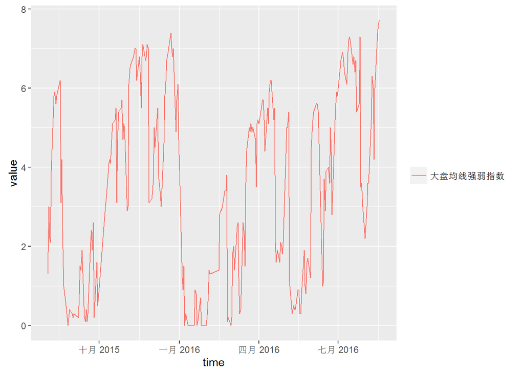

申万一级行业的最新得分及上周得分见下表：

| 日期 | 指数代码 | 指数名称 | 最新值 | 上周值 |
| --- | --- | --- | --- | --- |
| 2016-08-18 | EI801010 | 申万农林牧渔 | 8 | 4 |
| 2016-08-18 | EI801020 | 申万采掘 | 8 | 8 |
| 2016-08-18 | EI801030 | 申万化工 | 8 | 4 |
| 2016-08-18 | EI801080 | 申万电子 | 8 | 3 |
| 2016-08-18 | EI801110 | 申万家用电器 | 8 | 4 |
| 2016-08-18 | EI801120 | 申万食品饮料 | 8 | 7 |
| 2016-08-18 | EI801130 | 申万纺织服装 | 8 | 0 |
| 2016-08-18 | EI801140 | 申万轻工制造 | 8 | 4 |
| 2016-08-18 | EI801150 | 申万医药生物 | 8 | 5 |
| 2016-08-18 | EI801180 | 申万房地产 | 8 | 6 |
| 2016-08-18 | EI801200 | 申万商业贸易 | 8 | 6 |
| 2016-08-18 | EI801230 | 申万综合 | 8 | 8 |
| 2016-08-18 | EI801710 | 申万建筑材料 | 8 | 7 |
| 2016-08-18 | EI801720 | 申万建筑装饰 | 8 | 7 |
| 2016-08-18 | EI801730 | 申万电气设备 | 8 | 2 |
| 2016-08-18 | EI801770 | 申万通信 | 8 | 4 |
| 2016-08-18 | EI801780 | 申万银行 | 8 | 8 |
| 2016-08-18 | EI801790 | 申万非银金融 | 8 | 5 |
| 2016-08-18 | EI801880 | 申万汽车 | 8 | 4 |
| 2016-08-18 | EI801040 | 申万钢铁 | 7 | 7 |
| 2016-08-18 | EI801050 | 申万有色金属 | 7 | 4 |
| 2016-08-18 | EI801160 | 申万公用事业 | 7 | 7 |
| 2016-08-18 | EI801170 | 申万交通运输 | 7 | 1 |
| 2016-08-18 | EI801210 | 申万休闲服务 | 7 | 0 |
| 2016-08-18 | EI801740 | 申万国防军工 | 7 | 3 |
| 2016-08-18 | EI801750 | 申万计算机 | 7 | 0 |
| 2016-08-18 | EI801760 | 申万传媒 | 7 | 0 |
| 2016-08-18 | EI801890 | 申万机械设备 | 7 | 1 |

### (二)LLT及均线择时

LLT本质上是一个改进的单均线择时指标，较原始的均线择时延迟更低。  
择时模型和指数本身的净值走势如下图：

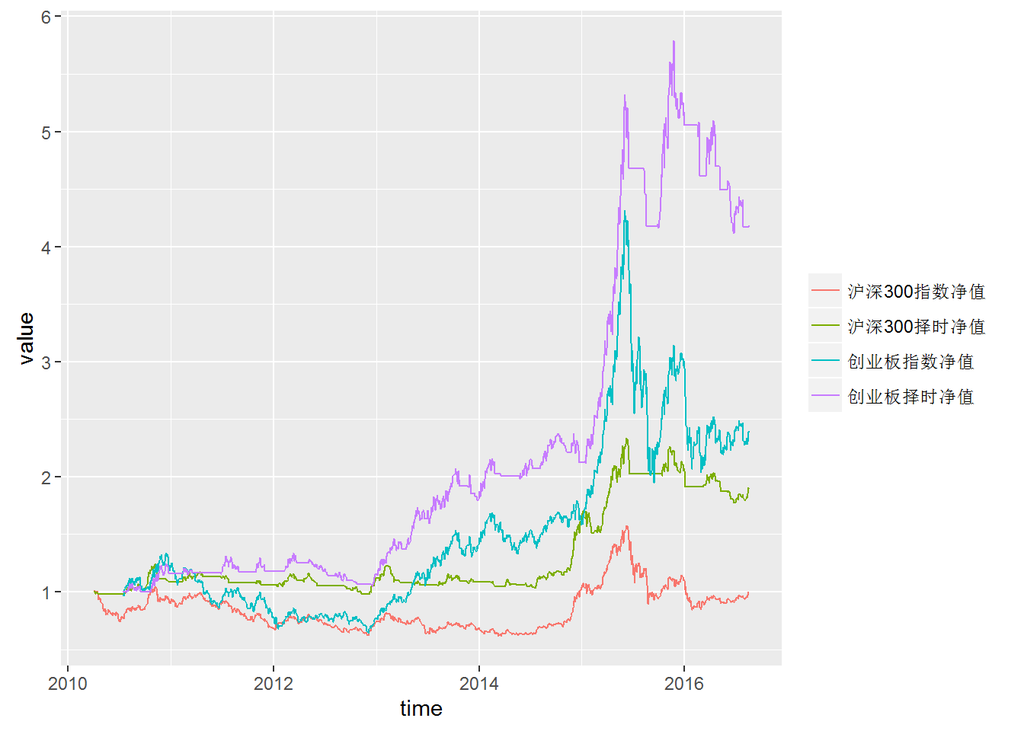

择时模型和指数的收益率统计如下表：

|  | 沪深300指 | 沪深300LLT | 创业板指 | 创业板MA |
| --- | --- | --- | --- | --- |
| 年化收益率 | 0.00 | 0.11 | 0.16 | 0.27 |
| 年化波动率 | 0.26 | 0.16 | 0.35 | 0.24 |
| 年化Sharpe值 | -0.01 | 0.66 | 0.46 | 1.15 |
| 最大回撤 | 0.47 | 0.24 | 0.55 | 0.29 |

择时模型最近10个交易日的信号如下表：

| 日期 | 沪深300收盘价 | 沪深300择时信号 | 创业板收盘价 | 创业板择时信号 |
| --- | --- | --- | --- | --- |
| 2016-08-05 | 3205.110 | hold | 2109.055 |  |
| 2016-08-08 | 3234.183 | hold | 2130.594 |  |
| 2016-08-09 | 3256.981 | hold | 2154.505 |  |
| 2016-08-10 | 3243.341 | hold | 2137.001 |  |
| 2016-08-11 | 3233.360 | hold | 2103.395 |  |
| 2016-08-12 | 3294.234 | hold | 2123.841 |  |
| 2016-08-15 | 3393.424 | hold | 2193.211 |  |
| 2016-08-16 | 3378.245 | hold | 2201.096 | buy |
| 2016-08-17 | 3373.048 | hold | 2208.195 | hold |
| 2016-08-18 | 3364.485 | hold | 2201.594 | hold |

### (三)网格交易

在经历了三轮股灾，A股逐步回归正常，在过去的一段时间呈现一个震荡的格局，如果未来没有增量信息，很可能维持震荡。结合股指期货的贴水，前期研究了一下网格交易。网格交易的结果如下图：

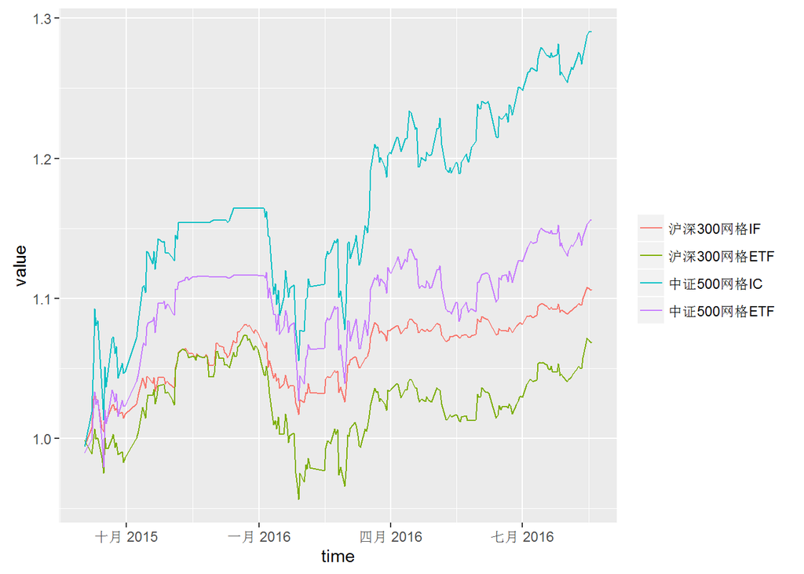

网格交易的收益统计如下表：

|  | 沪深300指数 | 沪深300网格IF | 沪深300网格ETF | 中证500指数 | 中证500网格IC | 中证500网格ETF |
| --- | --- | --- | --- | --- | --- | --- |
| 年化收益率 | 0.00 | 0.11 | 0.07 | 0.06 | 0.31 | 0.17 |
| 年化波动率 | 0.27 | 0.08 | 0.12 | 0.37 | 0.17 | 0.14 |
| 年化Sharpe值 | 0.00 | 1.46 | 0.62 | 0.15 | 1.85 | 1.24 |
| 最大回撤 | 0.26 | 0.06 | 0.11 | 0.33 | 0.09 | 0.08 |

### (四)银行股轮动

银行股轮动是参考集思录的热门贴银行股评级而来的，数据的提取和参数的设置和原贴有一定的差别，所以轮动的效果也会不太一样，不过回测的效果还不错，从现在开始跟踪。2012年以来银行股轮动的结果如下图：

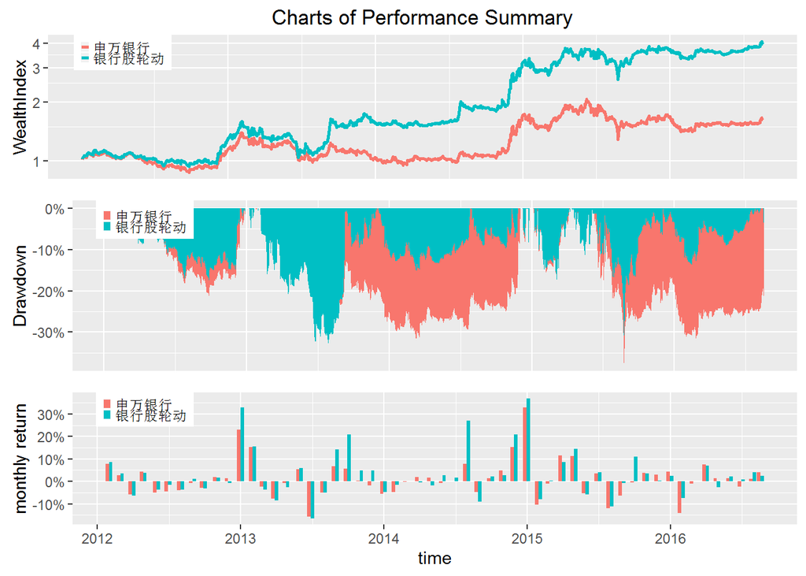

银行股轮动的收益统计如下表：

|  | 申万银行 | 银行股轮动 |
| --- | --- | --- |
| 2012-01-05 ~ 2012-12-31 | 0.16 | 0.31 |
| 2013-01-04 ~ 2013-12-31 | -0.09 | 0.20 |
| 2014-01-02 ~ 2014-12-31 | 0.63 | 1.02 |
| 2015-01-05 ~ 2015-12-31 | -0.01 | 0.17 |
| 2016-01-04 ~ 2016-08-18 | -0.04 | 0.06 |
| Cumulative Return | 0.62 | 2.93 |
| Annualized Return | 0.11 | 0.36 |

银行股轮动的最新持仓如下表：

| 日期 | 代码 | 简称 | PB | 预期ROE | 翻倍期 |
| --- | --- | --- | --- | --- | --- |
| 2016-08-11 | EQ601988 | 中国银行 | 0.78 | 0.12 | 3.95 |
| 2016-08-12 | EQ601988 | 中国银行 | 0.80 | 0.12 | 4.21 |
| 2016-08-15 | EQ601988 | 中国银行 | 0.82 | 0.12 | 4.36 |
| 2016-08-16 | EQ601988 | 中国银行 | 0.79 | 0.12 | 4.08 |
| 2016-08-17 | EQ601988 | 中国银行 | 0.79 | 0.12 | 4.05 |
| 2016-08-18 | EQ601988 | 中国银行 | 0.78 | 0.12 | 4.00 |